```python
import pandas as pd
import numpy as np
import matplotlib.pyplot as plt
import seaborn as sns
```

# 1. Loading the Data

First, we need to load the dataset and perform a basic inspection to understand its structure, data types, and potential issues like missing values or anomalies.

Also in order to make it easier we are going to define the target value as *y = "experimental_proprty"*

```python
# Load the dataset
df = pd.read_csv('hw1_dataset.csv')
y = "experimental_proprty"
columns = df.columns.values.tolist()

# Display basic information
print(df.info())
df.head()
```

```
<class 'pandas.core.frame.DataFrame'>
RangeIndex: 2000 entries, 0 to 1999
Columns: 552 entries, experimental_proprty to n6Ring
dtypes: float64(444), int64(105), object(3)
memory usage: 8.4+ MB
None
```

|  | experimental_proprty | MS_enc | nHetero | nX | C2SP3 | MPC5 | ATS0i | NaasN | SsCH3 | nCl | ... | AATS0Z | ATSC0are | ATSC2pe | SsCl | ATS6v | AATSC1dv | nFARing | AATS2v | Xp-7dv | n6Ring |
| --- | --- | --- | --- | --- | --- | --- | --- | --- | --- | --- | --- | --- | --- | --- | --- | --- | --- | --- | --- | --- | --- |
| 0 | 3.54 | PPENPINEAPLE42 | 5 | 1 | 0 | 83 | 7305.483137 | 1 | 2.105782 | 1 | ... | 26.444444 | 2.995920 | -0.508149 | 5.976320 | 16177.071020 | 1.102539 | 0 | 223.767000 | 0.903808 | 3 |
| 1 | -1.18 | PPENPINEAPLE42 | 11 | 0 | 3 | 114 | 9532.633527 | 0 | 4.605907 | 0 | ... | 31.796610 | 9.996180 | 2.554415 | 0.000000 | 29893.511410 | 0.854039 | 1 | 225.916087 | 1.887922 | 3 |
| 2 | 3.69 | PPENPINEAPLE42 | 5 | 1 | 2 | 69 | 5845.023999 | 0 | 1.422763 | 1 | ... | 35.513514 | 3.773573 | -0.113725 | 6.285975 | 17264.331087 | 0.793417 | 1 | 241.492298 | 1.098203 | 2 |
| 3 | 3.37 | HTXPTDWTTWOBJR | 9 | 1 | 3 | 105 | 7388.625069 | 0 | 0.000000 | 1 | ... | 35.869565 | 6.699887 | -0.114253 | 5.958016 | 20506.327989 | 0.421656 | 1 | 254.318903 | 1.164550 | 2 |
| 4 | 3.10 | PPENPINEAPLE42 | 7 | 0 | 2 | 68 | 9082.560968 | 1 | 9.734779 | 0 | ... | 21.018182 | 5.862455 | 1.664804 | 0.000000 | 22748.101433 | 1.602810 | 0 | 207.685522 | 0.492884 | 1 |

5 rows × 552 columns

# 2. Data Types Analysis

Next, we'll check if the columns are appropriately typed. Sometimes numeric data is read as strings, which could lead to issues in analysis.

```python
df.select_dtypes(include=["object"])
```

|  | MS_enc | MIF | SMIF |
| --- | --- | --- | --- |
| 0 | PPENPINEAPLE42 | Computation failed | bigger |
| 1 | PPENPINEAPLE42 | 59 | the_biggest |
| 2 | PPENPINEAPLE42 | 37 | big |
| 3 | HTXPTDWTTWOBJR | 46 | bigger |
| 4 | PPENPINEAPLE42 | 55 | bigger |
| ... | ... | ... | ... |
| 1995 | PPENPINEAPLE42 | 68 | the_biggest |
| 1996 | PPENPINEAPLE42 | 45 | bigger |
| 1997 | VMZXVMIGMRZLPU | 56 | bigger |
| 1998 | HTXPTDWTTWOBJR | 42 | bigger |
| 1999 | PPENPINEAPLE42 | 50 | bigger |

2000 rows × 3 columns

```python
df["SMIF"].unique()
```

```
array(['bigger', 'the_biggest', 'big'], dtype=object)
```

After checking this columns we can conclude that

1. We can clearly see that **MIF** is a numeric column with "Computational failed" mapped as NaN values.
2. Also, **SMIF** is a categorical feature with only 3 possible values, ["big", "bigger", "the_biggest"]

now, we are going to solve this

```python
df["MIF"] = df["MIF"].apply(lambda x : np.nan if x == "Computation failed" else x).astype("float64")
non_numeric_names = df.select_dtypes(include=["object"]).columns.values.tolist()
non_numeric_names
```

```
['MS_enc', 'SMIF']
```

# 3. Missing Values and Numerical Data

Missing values can distort the analysis, so we need to identify and decide how to handle them. We also need to only take for now all the numeric data for the future analysis.

Pd: we already now that "MIF" column is going to have some Nan values, as we define them ourselves before.

```python
df.loc[:, df.isna().any()].isna().sum()
```

```
MW2    100
MIF    100
dtype: int64
```

Comments before doing any operations:

1. **Drop columns**: We just have 2 (numerical) columns with nan values. Knowing the fact that we have 552 columns, 550 of which are numerical doesn't matter if we just skip this 2 columns for the analysis.
2. **Drop rows**: Also we could think that we just have (100+100 <= 200) rows with Nan values and 2000 rows. Dropping them is an option but now we are talking about around 10% of the data which it's a considerable amount.
3. **Fillna**: Another option is to fill our numerical Nan values with some sort of mean, median, ... value.

I'm going to choose to choose fillna as there are not many nan values, which they are not going to affect much in their own column, but instead I dont want to get rid of all the other data just for a few Nan values in one column/row. Before selecting the function I'm going to analyse the columns data distribution (as we just have 2) and then select the best option.

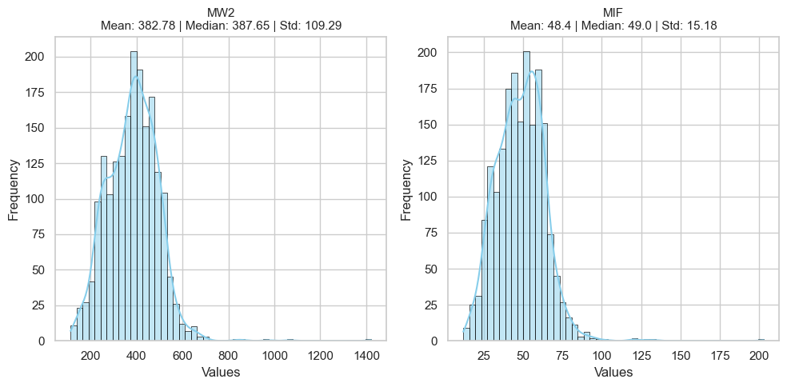

```python
sns.set(style="whitegrid")
fig, axes = plt.subplots(1, 2, figsize=(10, 5))

for i, c in enumerate(["MW2", "MIF"]):
    values = df[c].dropna()
    mean = round(values.mean(), 2)
    median = round(values.median(), 2)
    std  = round(values.std(), 2)

    sns.histplot(values, bins=50, kde=True, ax=axes[i], color="skyblue", edgecolor='black')

    axes[i].set_title(f"{c}\nMean: {mean} | Median: {median} | Std: {std}", fontsize=11)
    axes[i].set_xlabel('Values')
    axes[i].set_ylabel('Frequency')

plt.tight_layout()
plt.show()
```

After this analysis, I'm going to create a new dataframe called **data** in which is going to be all the numerical data without any Nan values, in order to use it for future analysis.

```python
numeric_names = [x for x in columns if x not in non_numeric_names]
data = df[numeric_names].fillna(df[numeric_names].median())
```

# 4. Outlier Detection

Outliers can heavily influence statistical measures and models. We will detect them using Z-scores and possibly remove those who are more than 3 std away from the mean and see how much data we'll keep.

This z-scores are meant to be used if the data follows a normal distribution, which we are just assuming it is. Probably is not, or at least not all the columns so we're not going to get good results...

```python
from scipy import stats

# Detect outliers using Z-score
z_scores = np.abs(stats.zscore(data))
outliers = (z_scores > 3)

# Remove rows where any feature has an outlier value
df_no_outliers = data[(outliers == False).all(axis=1)]

print(f"Data shape before removing outliers: {data.shape}")
print(f"Data shape after removing outliers: {df_no_outliers.shape}")
```

```
Data shape before removing outliers: (2000, 550)
Data shape after removing outliers: (657, 550)
```

We're dropping 67% of the data $\left(\frac{2000-657}{2000} = 0.67 \right)$ using this method! This isn't practical for real-world analysis, as it results in analyzing only a small portion of the data.

A better approach is to treat each row as a single data point and calculate multidimensional z-scores. This makes more sense because analyzing features individually ignores the relationships between them. For instance, an outlier in column $n_k$ might not be an outlier when considering the other features together. The multidimensional analysis considers the entire context, identifying true outliers by evaluating each row as a unique entity.

```python
from sklearn.preprocessing import StandardScaler

# Standardize the data (important for PCA)
scaler = StandardScaler()
scaled_data = pd.DataFrame(scaler.fit_transform(data.drop(columns=[y])), columns=data.columns.drop(y))

# Distance l2
distances =  scaled_data.apply(lambda x: np.sqrt(np.sum(x ** 2)), axis=1)

# z-scores
zscores_multidim = np.abs(stats.zscore(distances))
```

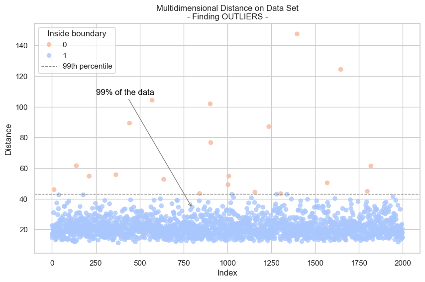

```python
q = distances.quantile(0.99)
n = len(distances)

plt.figure(figsize=(10, 6))

sns.scatterplot(x=range(n), y=distances, hue=(distances < q).astype("int"),
                palette="coolwarm_r", s=40, edgecolor=None, alpha=0.8)

plt.annotate("99% of the data", xy=(2 * n // 5, 4 * q // 5), xytext=(n // 8, 2.5 * q),
             arrowprops=dict(color='gray', arrowstyle='->'), fontsize=12, color='black')

plt.axhline(y=q, color='gray', linestyle='--', linewidth=1, label='99th percentile')
plt.xlabel('Index')
plt.ylabel('Distance')
plt.title('Multidimensional Distance on Data Set\n- Finding OUTLIERS -')
plt.legend(title='Inside boundary')
plt.show()
```

Now we can observe that we found much less outliers and maybe more accurate than the previous local ones. In order to do that we are going to plot a histogram of the z-scores. As there is a huge diference between the counting in diferent levels, I'm going to use a logarithmic scale to be able to improve our extraction of meaning from the output.

```
multidim z-scores [90% quantile]: 1.1168205724727502
z-scores [90% quantile]: 1.5169262953705958
```

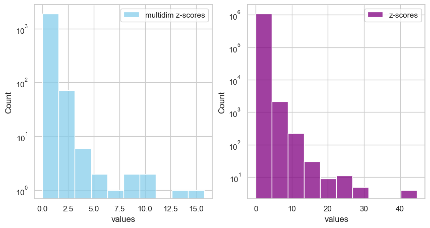

```python
fig, axes = plt.subplots(1, 2, figsize=(10, 5))

zs = [zscores_multidim, z_scores.dropna(axis=1).values.flatten()]
cs = ["skyblue", "purple"]
ls = ["multidim z-scores", "z-scores"]

print(f"{ls[0]} [90% quantile]: {zs[0].quantile(0.9)}")
print(f"{ls[1]} [90% quantile]: {np.quantile(zs[1], 0.9)}")

for i in range(2):
    sns.histplot(zs[i], bins=10, ax=axes[i], color=cs[i], label=ls[i], edgecolor='white')
    axes[i].set_yscale("log")
    axes[i].set_xlabel("values")
    axes[i].legend()

plt.show()
```

Now we see our improvements. I'm going to choose $n=3$ for the number of std away from the mean which I'm going to consider outliers. We can see that we just take out 16 data points.

We know that if we would choose $n=1.1168$ we would get rid of 10% of the data which is not that bad. This choice depends on how strict we want to be with the study.

```python
data_cleaned = data.loc[zscores_multidim < 3, :]
data_cleaned.shape
```

```
(1984, 550)
```

# 5. Correlation between variables

We’ll now check for highly correlated variables.

```python
corr = data.drop(columns=[y]).corr()
```

Now, as we have a lot of values here, I'm going to plot a histogram in which we can see more less how many variables are well correlated and which not. Also we are going to get the best correlations and study them. For that, I'm going to divide the histogram in 2, one for the positive correlations and one for the negatives.

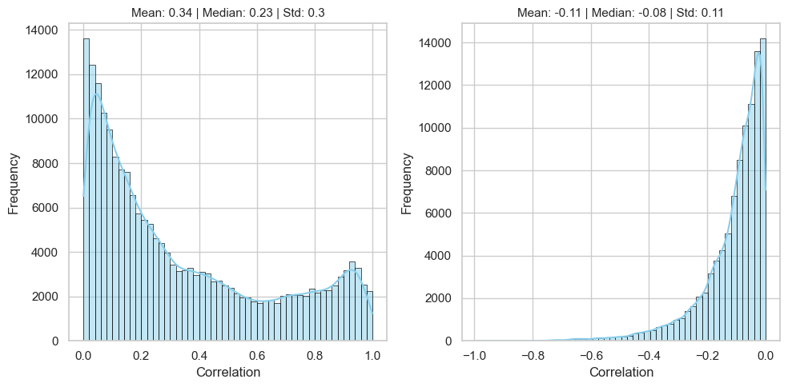

```python
corr_list = corr.unstack()

# general histogram
sns.set(style="whitegrid")
fig, axes = plt.subplots(1, 2, figsize=(10, 5))

for i, f in enumerate([lambda x : x > 0, lambda x : x < 0]):
    plt.subplot(1,2,i+1)
    values = corr_list[f(corr_list)]
    mean = round(values.mean(), 2)
    median = round(values.median(), 2)
    std  = round(values.std(), 2)

    sns.histplot(values, bins=50, kde=True, ax=axes[i], color="skyblue", edgecolor='black')

    axes[i].set_title(f"Mean: {mean} | Median: {median} | Std: {std}", fontsize=11)
    axes[i].set_xlabel('Correlation')
    axes[i].set_ylabel('Frequency')

plt.tight_layout()
plt.show()
```

As we can see, there aren't many negative correlations, but there are a large number of strong positive correlations (thousands of feature pairs with over 95% correlation). If two variables are more than 95% correlated, they essentially provide the same information. So...

Why Drop One of Highly Correlated Variables?

1. Redundancy: When two variables are highly correlated, they carry similar information about the variance in the data. Keeping both doesn't add much value and can lead to redundancy.
2. Multicollinearity: In regression models or algorithms sensitive to feature collinearity (like linear regression), high correlation between features can cause multicollinearity. This can make the model's coefficients unstable and harder to interpret.
3. Simplicity: Reducing the number of features simplifies the model, making it easier to interpret and potentially faster to train.
4. Overfitting: In some cases, highly correlated features can lead to overfitting, where the model learns the noise in the training data rather than the underlying pattern.

This brings us to the 'dimension reduction' section, where we'll use more advanced methods. For now, consider this a basic example of how we can reduce dimensions in our data. More complex algorithms can take this even further. But first, let's do a quick demonstration of how we can safely remove some columns without losing important information.

It's a tricky algorithm because the pairs overlap, so we need to be careful when dropping values. First, we'll gather all pairs with more than 95% correlation. After collecting them, we'll drop the pairs one by one in a specific order. In a while loop, we'll pick a pair, choose one value to keep and the other to drop. Then, we'll remove every pair related to the value we're keeping. We'll repeat this process until all pairs are handled.

```python
c95 = np.array(corr_list[np.abs(corr_list) > 0.95].sort_values(ascending=False).index.tolist())
c95_values = set(c95.flatten())
c95 = pd.DataFrame({"p1":c95[:,0], "p2":c95[:,1]})

dropping_columns = set()
maintain_columns = set()

while len(c95) > 0:

    index = c95.index[0]

    if c95["p1"][index] in dropping_columns:
        if c95["p2"][index] in dropping_columns:
            c95 = c95.drop(index=[index])
            continue
        else:
            name = c95["p2"][index]
            name_toDrop = c95["p1"][index]
    else:
        name = c95["p1"][index]
        name_toDrop = c95["p2"][index]

    maintain_columns.add(name)
    dropping_columns.add(name_toDrop)

    s1 = set(c95["p2"][c95["p1"] == name].values.tolist())
    s2 = set(c95["p1"][c95["p2"] == name].values.tolist())
    s = s1.union(s2)
    dropping_columns = dropping_columns.union(s)

    c95 = c95[(c95["p1"] != name) & (c95["p2"] != name)]

final_drops = c95_values - maintain_columns
len(final_drops)
```

```
245
```

With this result we would get rid of 245 columns, just by deleting the columns that has more than 95% correlation between each other (represents basically the same data as the other columns that we maintain). That's a huge improvement in this dataset as we are deleting almost 50% of the data (that seems not to be very useful) which is going to help to create better predictive models on the future.

# 6. Correlation with the target

## Linear correlation

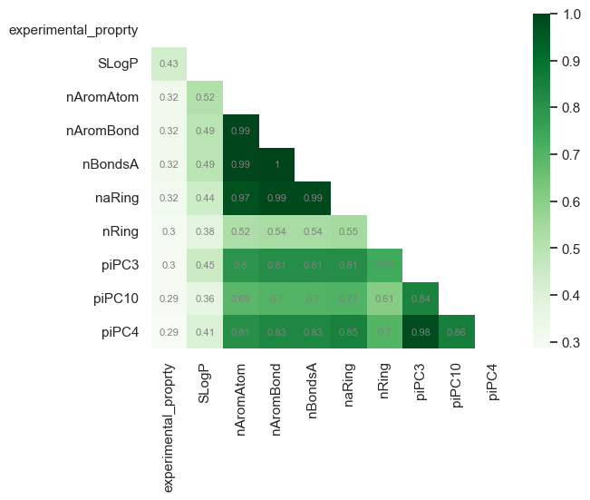

```python
corr = data.corr()
corr_target = corr[y].sort_values(ascending=False)

n = 10
sns.set(style="white")
mask = np.triu(np.ones_like(np.zeros((n,n)), dtype=bool))
l = corr_target[:n].index.values.tolist()
sns.heatmap(corr.loc[l, l], cmap="Greens", mask = mask, annot=True, annot_kws={"fontsize": 8, "fontweight": "1", "color": "gray"})
plt.show()
```

In the first column (the important here) we have some decent correlations (with the target value) from 0.3 to a maximum of 0.43. Also between some of these best correlated features we observed high correlations up to 1. In order to visualize this correlations we are going to select the best 5 and make a pairplot.

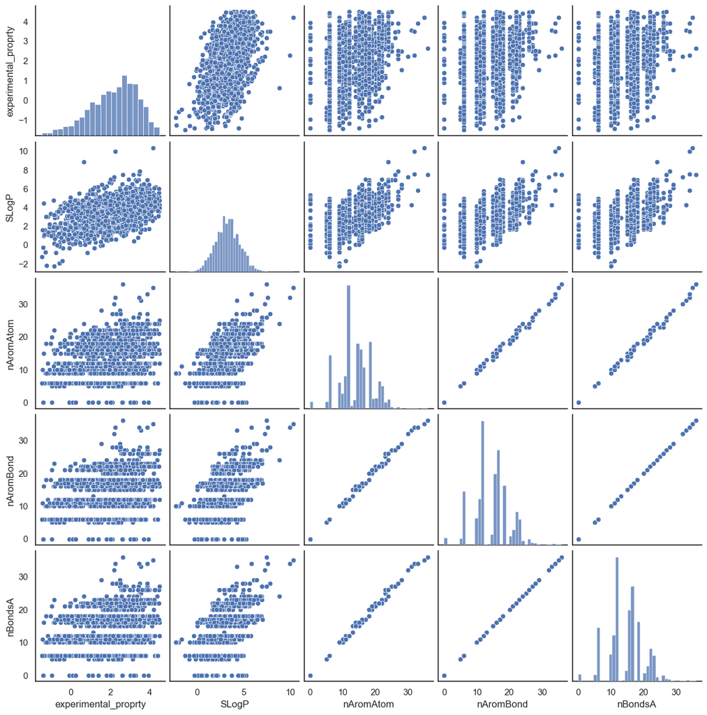

```python
sns.pairplot(data.loc[:,l[:5]])
```

## Quadratic correlation

Another possible study is the quadratic correlation (for quadratic models). This ca be done by taking $x^2$ from every data-point of the dataframe and the do a normal correlation between them. In this case I just want to now correlations with the target value as the other ones are not very usuful for now.

```python
corr2 = data.drop(columns=[y]).map(lambda x : x**2).apply(lambda x: data[y].corr(x))
corr2 = pd.DataFrame({"feature":corr2.index,"corr":corr2.values}).dropna(axis=0).sort_values(by="corr", ascending=False)
```

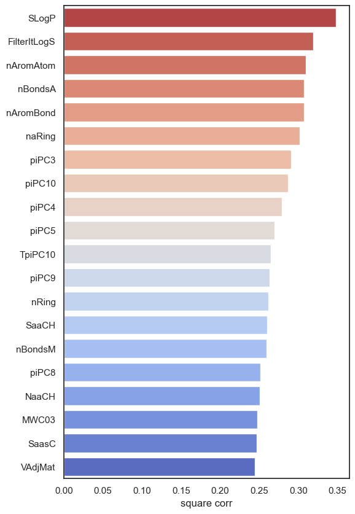

```python
n = 20
plt.figure(figsize=(6,10))
sns.barplot(x='corr', y='feature', data=corr2[:n],
                            orient='h', palette=sns.color_palette("coolwarm_r", n), legend=False)
plt.ylabel("")
plt.xlabel("square corr")
plt.show()
```

We found that **SLogP** is also the best quadratic-correlated with the target, as it was the best linear-correlated. On the other side, we find other new best correlations such as **FilterItLogS** as the second best, which didn't apear on the other best-10 linear correlations.

Comment: eventhough less than 40% correlation doesn't mean much, we have to have in mind that we have multiple variables and we are only measuring it with one at a time. Therefore, if we found some linear or quadratic small correlation with it, that could mean that the target has a posible polinomial correlation with several features.

# 7. Dimensionality reduction

## Principal Component Analysis (PCA)

PCA helps in dimensionality reduction by finding linear combinations of variables that explain the most variance. First we are going to reduce the data by setting our PCA to explain 95% of the data variance, therefore we wont lose too much data-meaning and in the other side we'll significantly reduce our number of dimensions.

In order to have a PCA visualixation we'll plot the best 2 of this selected components.

```
(2000, 60)
```

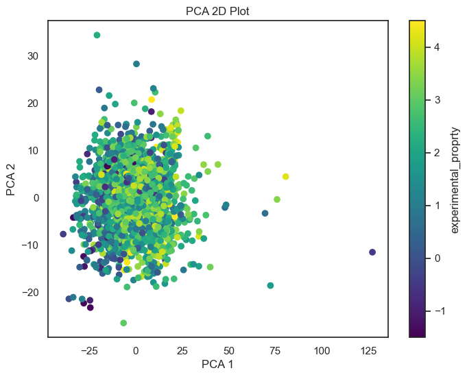

```python
from sklearn.decomposition import PCA

# Apply PCA
pca = PCA(0.95)
pca_result = pca.fit_transform(scaled_data)
print(pca_result.shape)

# Plot PCA result, color by target property
plt.figure(figsize=(8,6))
plt.scatter(pca_result[:, 0], pca_result[:, 1], c=data[y], cmap='viridis')
plt.colorbar(label=y)
plt.xlabel('PCA 1')
plt.ylabel('PCA 2')
plt.title('PCA 2D Plot')
plt.show()
```

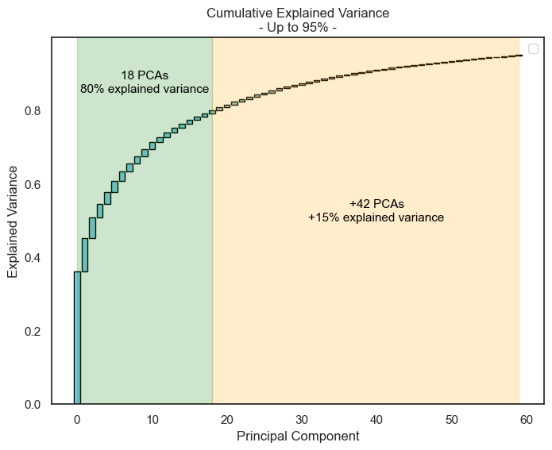

```python
explained_variance = pca.explained_variance_ratio_
cumulative_variance = np.cumsum(explained_variance)
starting_points = np.insert(cumulative_variance[:-1], 0, 0)

plt.figure(figsize=(8, 6))
plt.bar(range(len(explained_variance)), explained_variance,
        bottom=starting_points, color='skyblue', edgecolor='black')

plt.axvspan(0, 18, color='green', alpha=0.2)
plt.axvspan(18, 59, color='orange', alpha=0.2)
plt.text(9, 0.85, '18 PCAs\n80% explained variance', fontsize=11, color='black', ha='center')
plt.text(40, 0.5, '+42 PCAs\n+15% explained variance', fontsize=11, color='black', ha='center')

plt.xlabel('Principal Component')
plt.ylabel('Explained Variance')
plt.title('Cumulative Explained Variance\n- Up to 95% -')

plt.show()
```

## Non-Linear Dimensionality Reduction (t-SNE)

For this step, we’ll use a non-linear dimensionality reduction technique like t-SNE and compare the results with PCA. For that we're going to test it with different perplexity values.

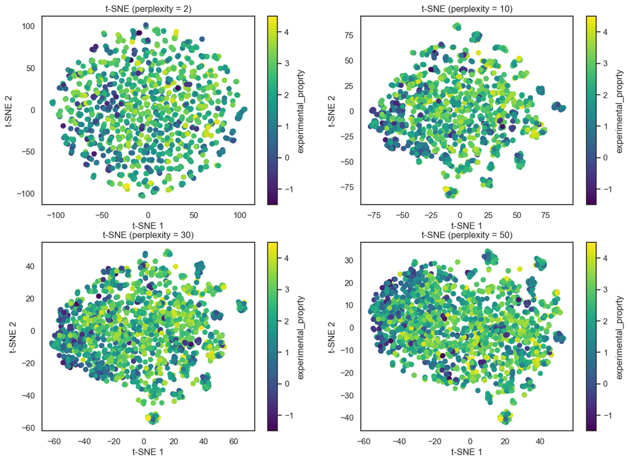

```python
from sklearn.manifold import TSNE

plt.subplots(2, 2, figsize=(14, 10))

# try diferent perplexities
i = 0
for perplexity in [2, 10, 30, 50]:
    i += 1

    # Apply t-SNE
    tsne = TSNE(n_components=2, perplexity=perplexity, random_state=0)
    tsne_result = tsne.fit_transform(scaled_data)

    # Plot t-SNE result, color by target property
    plt.subplot(2,2,i)
    plt.scatter(tsne_result[:, 0], tsne_result[:, 1], c=data[y], cmap='viridis')
    plt.colorbar(label=y)
    plt.xlabel('t-SNE 1')
    plt.ylabel('t-SNE 2')
    plt.title(f't-SNE (perplexity = {perplexity})')

plt.show()
```

Also we are going to apply this method to the already reduce data frame made with the PCA and see if we can get a better reduction by combining both algorithms.

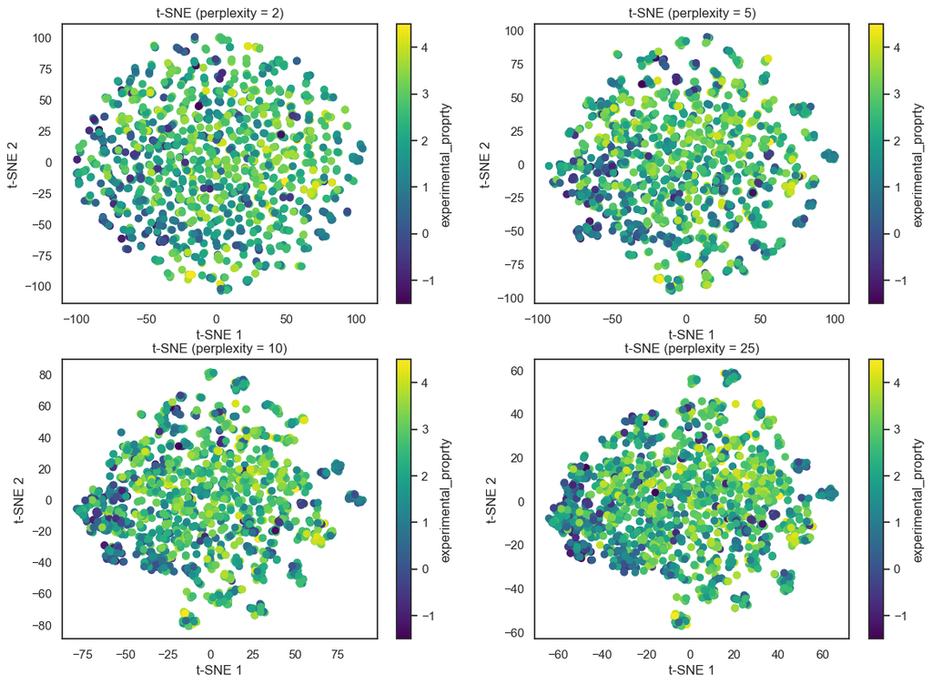

```python
from sklearn.manifold import TSNE

plt.subplots(2, 2, figsize=(14, 10))

# try diferent perplexities
i = 0
for perplexity in [2, 5, 10, 25]:
    i += 1

    # Apply t-SNE
    tsne = TSNE(n_components=2, perplexity=perplexity, random_state=0)
    tsne_result = tsne.fit_transform(pca_result)

    # Plot t-SNE result, color by target property
    plt.subplot(2,2,i)
    plt.scatter(tsne_result[:, 0], tsne_result[:, 1], c=data[y], cmap='viridis')
    plt.colorbar(label=y)
    plt.xlabel('t-SNE 1')
    plt.ylabel('t-SNE 2')
    plt.title(f't-SNE (perplexity = {perplexity})')

plt.show()
```

In both cases, due to the large number of data points, it is challenging to extract any significant insights directly from the plots. However, we do observe a small cluster of points in the lower part of the visualization for the last three perplexity values in both figures. It's important to remember that in the t-SNE algorithm, the proximity of two points is meaningful, indicating similarity, but the distance between distant points does not carry a significant interpretation.

# 8. Conclusion

This exploratory data analysis (EDA) provided a comprehensive examination of a complex dataset, `df`, with over 500 features and 2000 observations. We began by identifying and correcting data type issues, particularly focusing on object-type columns that contained numeric data but had some non-numeric entries. By cleaning these columns and converting them to the correct data type, we ensured a more consistent dataset for subsequent analyses.

In the process of handling missing values, we opted to isolate the numerical data into a new DataFrame, `data`. We discuss different strategies for managing the missing values, including filling them with median values and dropping rows or columns where appropriate. This preprocessing step was crucial in maintaining the integrity of the dataset.

For outlier detection, we employed **Z-scores** to identify and handle outliers. By exploring both unidimensional and multidimensional Z-scores, we were able to refine our detection process and identify a more reasonable number of outliers, minimizing the risk of removing too many legitimate observations. This step helped to reduce the impact of extreme values on subsequent analyses. The resultant data frame was called `data_cleaned`.

Moving to the correlation analysis, we discovered a significant number of highly correlated features, with more than **95% correlation**. To mitigate multicollinearity, we removed these highly correlated features, resulting in the elimination of 245 columns, `final_drops`, roughly 50% of the dataset. This reduction was essential in simplifying the dataset and improving the performance of any models that might be built in the future.

We also investigated the correlation, `corr`, between the features and the target variable, `experimental_proprty`. This involved not only exploring linear correlations but also examining quadratic relationships by transforming the features. This deeper look at potential associations provided a better understanding of the relationships within the dataset.

Finally, we applied dimensionality reduction techniques to visualize the dataset and uncover underlying patterns. Using Principal Component Analysis (**PCA**) and t-Distributed Stochastic Neighbor Embedding (**t-SNE**), we initially reduced the dataset to two dimensions for visualization purposes, allowing us to identify clusters and trends within the data. This strict reduction was specifically for visualization; in a real modeling scenario, we would reduce the dimensions only to a level that preserves the meaningful variance in the data while still allowing for manageable input sizes. In practice, as we did with PCA, we retained 60 components instead of just two, ensuring that we maintained a balance between dimensionality reduction and the interpretability of the data. This approach would similarly apply to using the t-SNE algorithm in a modeling context.

In summary, this EDA involved a series of methodical steps to clean, process, and explore the dataset, culminating in a more manageable set of features and a better understanding of the relationships within the data. By addressing data quality issues, handling outliers, reducing dimensionality, and exploring correlations, we have prepared the dataset for more advanced analyses and potential modeling.